# Slide Notes: 24-32

David J. Hunter

This page contains the content of all the slides for the material that we covered in Chapters 7,8,10, and 11 of [Algorithms](http://jeffe.cs.illinois.edu/teaching/algorithms/book/Algorithms-JeffE.pdf), by Jeff Erickson. If you notice any errors, please [create a new issue](https://github.com/djhunter/algorithms/issues).

# Trees

## Applications of Trees

- Binary search trees
- Recursion trees
- DFS and BFS trees
- Binary heaps
- Huffman Codes
- etc.

Most of these trees had a preferred *root*, and a preferred *direction* (away from the root).

## Tree: General Definition

> A **tree** is a connected, acyclic graph.

By default, a generic tree is *undirected*. To understand this definition, we need to be precise about the meaning of *acyclic*.

- A **walk** in an undirected graph $G$ is a sequence of vertices, where each adjacent pair of vertices are adjacent in $G$.
- A walk is **closed** if it starts and ends at the same vertex.
- A walk is called a **path** if it visits each vertex at most once.
- A **cycle** is a closed walk that enters and leaves each vertex at most once.
- An undirected graph is **acyclic** if no subgraph is a cycle.

## Unravel the definitions

1. Draw an example of a walk that is not a path.
2. Draw an example of a closed walk that is not a cycle.
3. What is a closed path? Can you draw an example?
4. Draw a tree with 6 vertices. How many edges does it have?
5. How many edges does a tree with $n$ vertices have? Can you prove your answer?

## Table Groups

| Table #1 | Table #2 | Table #3 | Table #4 | Table #5 | Table #6 | Table #7 |
| --- | --- | --- | --- | --- | --- | --- |
| Bri | Logan | Kristen | Trevor | Claire | Graham | Blake |
| Andrew | Jordan | Levi | Josiah | Ethan | James | Nathan |
| Jack | Grace | Isaac | Talia | Kevin | Drake | John |

# Paths in trees

## Unique Paths

**Lemma.** Suppose $T$ is a tree, and $u$ and $v$ are two vertices in $T$. Then there is a unique path from $u$ to $v$.

- There exists a path from $u$ to $v$ because $T$ is connected.
- Suppose to the contrary that there are two different paths from $u$ to $v$.
  - Path 1: $a_0 = u, a_1, a_2, \ldots, a_k = v$.
  - Path 2: $b_0 = u, b_1, b_2, \ldots, b_j = v$.
    - Let $a_s = b_s$ be the last vertex at the start of these paths that are the same.
    - Let $a_{k-e} = b_{j-e}$ be the first vertex at the end of these paths that are the same.
  - Then $a_s, \ldots, a_{k-e}, b_{j-e-1}, \ldots, b_s$ is a cycle, contradicting that $T$ is a tree.

## Equivalent Condition

The converse of the Lemma is also true: If $G$ is a graph with the property that every pair of vertices are joined by a unique path, then $G$ is a tree.

- Connected: $\checkmark$
- Acyclic: A cycle would contradict the unique path condition.

# Weighted Graphs

## Weighted Edges

A graph is called *weighted* if there is an assignment of real numbers (weights) to the edges. For example,

- Cost function in a network.
- Distance function in a spatial arrangement.

## Minimum Spanning Tree of a Weighted Graph

Given a weighted graph $G$, a **minimum spanning tree** $T$ is a subgraph of $G$ such that:

- $T$ contains all the vertices of $G$, and
- The sum of weights of the edges of $T$ is as small as possible.
6. Why do the above two conditions guarantee that $T$ is a tree?
7. Draw an example of a weighted graph with two different minimum spanning trees (if possible).
8. Draw an example of a weighted graph with a unique smallest edge $e$, such that the minimum spanning tree does not contain $e$ (if possible).

# Uniqueness

## Minimum spanning is unique (almost)

**Lemma.** If all edge weights in a connected graph $G$ are distinct, then $G$ has a unique minimum spanning tree.

- Suppose $G$ has two minimum spanning trees $T$ and $T'$.
- Let $e$ be the smallest edge in $(T\setminus T')\cup(T'\setminus T)$.
  - WLOG, $e\in T\setminus T'$.
- Adding this edge to $T'$ creates a cycle.
  - One of the edges in this cycle is not in $T$.
  - Exchange this edge for $e$, and you reduce the weight of $T'$, a contradiction.

# Minimum Spanning Trees

# Trees

## Tree: Definition and equvalent notions

A **tree** is a *connected*, *acyclic* graph. (By default, a generic tree is *undirected*.) Equivalently,

- *Unique paths:* A tree is an undirected graph $T$ such that, for any two vertices $u$ and $v$ in $T$, there is a unique path from $u$ to $v$.
- *$V-1$ edges:* A tree is a connected, undirected graph with $V-1$ edges.
  - *Can’t add an edge:* Adding an edge to a tree makes a cycle.

## Minimum Spanning Tree of a Weighted Graph

- A graph is called *weighted* if there is an assignment of real numbers (weights) to the edges.
- Given a weighted graph $G$, a **minimum spanning tree** $T$ is a subgraph of $G$ such that:
  - $T$ contains all the vertices of $G$, and
  - The sum of weights of the edges of $T$ is as small as possible.
- Applications: network optimization, image recognition, data analysis, etc.

(See Jamboard from last time.)

## Table Groups

| Table #1 | Table #2 | Table #3 | Table #4 | Table #5 | Table #6 | Table #7 |
| --- | --- | --- | --- | --- | --- | --- |
| Levi | Kristen | Claire | Graham | Grace | Blake | Bri |
| Kevin | Trevor | Nathan | John | James | Drake | Isaac |
| Jordan | Jack | Josiah | Ethan | Andrew | Logan | Talia |

## Smallest edge

1. Let $G$ be a weighted graph with an edge $e$ that is lighter (i.e., smaller) than all the other edges. Prove that any minimum spanning tree must contain $e$.

Hints:

- Suppose to the contrary that $T$ is a minimum spanning tree of $G$ and that ___________________.
- What happens if you add an edge to $T$?
- Show you can make a lighter spanning tree (contradiction).

# Uniqueness

## Simplifying assumption: distinct weights

Without losing generality, we can *assume our edge weights are distinct.*

Why is this OK?

- In most applications, they are distinct.
- We could break ties by adding an insignificant $\varepsilon$ to a weight.
- We could break ties some other systematic way.
- Two floats are “never” equal (at least you shouldn’t expect them to be).

```r
sqrt(3)^2 == 3
```

```
[1] FALSE
```

## Two minimum spanning trees?

Suppose a connected, weighted, undirected graph $G$ has *distinct edge weights* and *two minimum spanning trees* $T$ and $T'$.

> - Suppose to the contrary that $T \neq T'$.
>   - Then there are edges in $T$ that are not in $T'$, and edges in $T'$ that are not in $T$. Let $e$ be the smallest of these edges.
>   - In other words, $e$ is the smallest edge in $(T\setminus T')\cup(T'\setminus T)$.
>   - WLOG, $e\in T\setminus T'$.
> - Adding this edge to $T'$ creates a cycle in $T'$.
>   - One of the edges in this cycle is not in $T$.
>   - Exchange this edge for $e$, and you reduce the weight of $T'$, a contradiction.

## **The** minimum spanning tree

We have proved the following.

**Lemma.** If all the edge weights of a graph are distinct, then its minimum spanning tree is *unique*.

So we will henceforth refer to “the” minimum spanning tree of a graph.

# Edge Classification

## Intermediate spanning forests

- We can build a spanning tree by selecting edges.
- At each stage, we avoid cycles, so we have a forest (maybe not a tree).

An *intermediate spanning forest* of a weighted graph $G$ is a subgraph of the minimum spanning tree of $G$.

## Safe and Useless edges

For any intermediate spanning forest $F$ of a graph $G$,

- An edge of $G$ is **useless** if it is not an edge of $F$, but both its endpoints are in the same component of $F$.
- An edge of $G$ is **safe** if it is the minimum-weight edge with exactly one endpoint in some component of $F$.

## Example

In the following graph $G$, the bold edges form an intermediate spanning forest $F$.

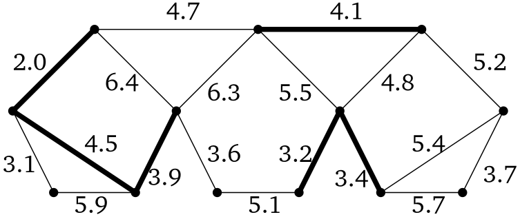

## Safe and Useless

2. Identify all the safe edges and all the useless edges.
3. What happens if you add a useless edge to $F$?
4. Add all the safe edges to $F$. Is the resulting forest $F'$ still an intermediate spanning forest?
5. Repeat: Add all of the safe edges of $F'$ to $F'$, and continue. How will this process terminate?

# Borůvka’s MST Algorithm

# Assignment Comments, Sample Solutions

## MST with largest edge

1. Give an example of a weighted undirected graph that is not a tree, but whose minimum spanning tree contains the largest edge in the graph.

```
         1.1
       0--------0
   6.7/ \        \2.4
     /   \5.2     0
    0     \       /2.3
           0-----0
             3.3
```

## Largest cycle edge excluded

2. Let $G$ be a weighted, undirected graph. Prove that for any cycle in $G$, the minimum spanning tree *does not include* the largest edge in the cycle.

(Common wrong answer on Jamboard.)

## Proof considering components (sketch)

- Suppose there exists a minimum spanning tree $T$ that includes a maximum edge $e_\text{max} = uv$ of some cycle. Remove $e_\text{max}$ from $T$.
- The tree is no longer a minimum spanning tree but instead two components, one containing $u$ and the other containing $v$. But since there was a cycle in $G$ containing $e_{max}$, there is a path in $G$ from $u$ to $v$. Therefore, some edge $e$ on this path must connect the two components.
- Exchange $e$ and $e_\text{max}$, contradicting minimality.

## Disprove with a counterexample

3. Prove or disprove: The minimum spanning tree of a weighted, undirected graph $G$ includes the smallest edge in *every* cycle in $G$.

```
     (10)     (3)      (11)
e --------- a --- b ----------- d
 \           \   /             /
  \_      (2) \ / (1)        _/
    \          c            /
     \_                   _/
       \                 /
   (16) \_             _/ (15)
          \           /
           \_       _/
             \     /
              \_ _/
                f
```